# An introduction to databases with dplyr

Lakin Wecker  
2018-07-20

### Outline

1. The what and the why of a databases
2. Querying data from a single table
3. An example database and some of its tables
4. Combining data from multiple tables in a single query

### What is a database?

[figure not shown]

- Stores your data
- Query your data
- Manipulate your data

### Types of databases

- Relational Databases
  - Structured Query Language - SQL
- NoSQL
  - these are varied and important ,but we're not covering them today.

### Why use a database?

- Atomicity
- Consistency
- Isolation
- Durability
- *ACID*

### Why use an SQL database?

- Efficient queries in the face of huge data sets
- Structure guarantees data looks the way you expect
- Concurrent access

### dplyr: Available databases

## PostgreSQL

[figure not shown]

### dplyr: SQLite3

- Embedded and easy to install
- Doesn't require you to run a separate program
- Is quite powerful

### dplyr: Lahman Database

http://lahman.r-forge.r-project.org/

- Pitching
- Hitting
- Fielding
- Other stats

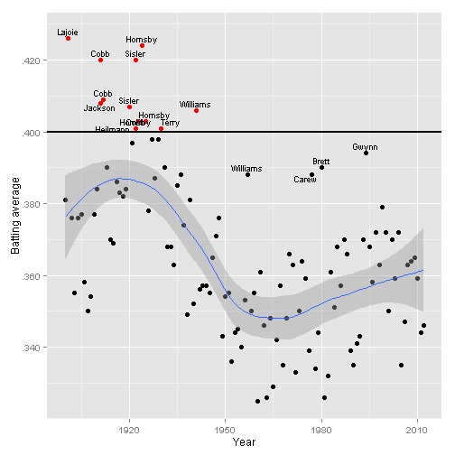

### dplyr: Installing the database

- Package installation order

```r
if(!require(RSQLite)) install.packages("RSQLite")
if(!require(dplyr)) install.packages("dplyr")
if(!require(dbplyr)) install.packages("dbplyr")
if(!require(Lahman)) install.packages("Lahman")
library(RSQLite)
library(dplyr)
library(dbplyr)
library(Lahman)
```

### dplyr: Connecting to a database

```r
src_sqlite()

src_postgresql()

src_mysql()

lahman_sqlite()
```

### dplyr: Connecting to Lahmann

```r
db_connection <- lahman_sqlite()
```

### dplyr: What data is available?

- Databases can contain many tables
- To see which ones are available, print the connection

```r
print(db_connection)
```

```
src:  sqlite 3.22.0 [/tmp/RtmpNzBmhK/lahman.sqlite]
tbls: AllstarFull, Appearances, AwardsManagers, AwardsPlayers,
  AwardsShareManagers, AwardsSharePlayers, Batting, BattingPost,
  CollegePlaying, Fielding, FieldingOF, FieldingPost, HallOfFame,
  LahmanData, Managers, ManagersHalf, Master, Pitching, PitchingPost,
  Salaries, Schools, SeriesPost, sqlite_stat1, sqlite_stat4, Teams,
  TeamsFranchises, TeamsHalf
```

### dplyr: Referencing a single table

First we have to tell dplyr which tables we will use.

```r
Batting <- tbl(db_connection, "Batting")
```

### dplyr: Exploring the structure

The `str()` function isn't particularly useful.

```r
str(Batting)
```

```
List of 2
 $ src:List of 2
  ..$ con  :Formal class 'SQLiteConnection' [package "RSQLite"] with 7 slots
  .. .. ..@ ptr                :<externalptr>
  .. .. ..@ dbname             : chr "/tmp/RtmpNzBmhK/lahman.sqlite"
  .. .. ..@ loadable.extensions: logi TRUE
  .. .. ..@ flags              : int 70
  .. .. ..@ vfs                : chr ""
  .. .. ..@ ref                :<environment: 0x563880afffd0>
  .. .. ..@ bigint             : chr "integer64"
  ..$ disco:<environment: 0x5638811853a8>
  ..- attr(*, "class")= chr [1:3] "src_dbi" "src_sql" "src"
 $ ops:List of 2
  ..$ x   : 'ident' chr "Batting"
  ..$ vars: chr [1:22] "playerID" "yearID" "stint" "teamID" ...
  ..- attr(*, "class")= chr [1:3] "op_base_remote" "op_base" "op"
 - attr(*, "class")= chr [1:4] "tbl_dbi" "tbl_sql" "tbl_lazy" "tbl"
```

### dplyr: Tibbles and their output.

Printing the table gives us the structure:

```r
print(Batting) # Does the same thing
```

```
# Source:   table<Batting> [?? x 22]
# Database: sqlite 3.22.0 [/tmp/RtmpNzBmhK/lahman.sqlite]
   playerID yearID stint teamID lgID      G    AB     R     H   X2B   X3B
   <chr>     <int> <int> <chr>  <chr> <int> <int> <int> <int> <int> <int>
 1 abercda…   1871     1 TRO    NA        1     4     0     0     0     0
 2 addybo01   1871     1 RC1    NA       25   118    30    32     6     0
 3 allisar…   1871     1 CL1    NA       29   137    28    40     4     5
 4 allisdo…   1871     1 WS3    NA       27   133    28    44    10     2
 5 ansonca…   1871     1 RC1    NA       25   120    29    39    11     3
 6 armstbo…   1871     1 FW1    NA       12    49     9    11     2     1
 7 barkeal…   1871     1 RC1    NA        1     4     0     1     0     0
 8 barnero…   1871     1 BS1    NA       31   157    66    63    10     9
 9 barrebi…   1871     1 FW1    NA        1     5     1     1     1     0
10 barrofr…   1871     1 BS1    NA       18    86    13    13     2     1
# ... with more rows, and 11 more variables: HR <int>, RBI <int>,
#   SB <int>, CS <int>, BB <int>, SO <int>, IBB <int>, HBP <int>,
#   SH <int>, SF <int>, GIDP <int>
```

### dplyr: Querying from a single table

Let's ask for all player ids with the year and the number of runs batted in (RBI):

```r
Batting %>% select(playerID, yearID, RBI)
```

```
# Source:   lazy query [?? x 3]
# Database: sqlite 3.22.0 [/tmp/RtmpNzBmhK/lahman.sqlite]
   playerID  yearID   RBI
   <chr>      <int> <int>
 1 abercda01   1871     0
 2 addybo01    1871    13
 3 allisar01   1871    19
 4 allisdo01   1871    27
 5 ansonca01   1871    16
 6 armstbo01   1871     5
 7 barkeal01   1871     2
 8 barnero01   1871    34
 9 barrebi01   1871     1
10 barrofr01   1871    11
# ... with more rows
```

### dplyr: Example Filter #1

Everyone that has had exactly 13 RBIs in a season:

```r
Batting %>%
  select(playerID, yearID, RBI) %>%
  filter(RBI == 13)
```

```
# Source:   lazy query [?? x 3]
# Database: sqlite 3.22.0 [/tmp/RtmpNzBmhK/lahman.sqlite]
   playerID  yearID   RBI
   <chr>      <int> <int>
 1 addybo01    1871    13
 2 birdge01    1871    13
 3 foleyto01   1871    13
 4 heubege01   1871    13
 5 patteda01   1871    13
 6 forceda01   1872    13
 7 murnati01   1872    13
 8 remseja01   1872    13
 9 mathebo01   1873    13
10 clackbo01   1874    13
# ... with more rows
```

### dplyr: Example Filter #2

Everyone that has had more than 170 RBIs in a season:

```r
Batting %>%
  select(playerID, yearID, RBI) %>%
  filter(RBI > 170)
```

```
# Source:   lazy query [?? x 3]
# Database: sqlite 3.22.0 [/tmp/RtmpNzBmhK/lahman.sqlite]
  playerID  yearID   RBI
  <chr>      <int> <int>
1 ruthba01    1921   171
2 gehrilo01   1927   175
3 gehrilo01   1930   174
4 wilsoha01   1930   191
5 gehrilo01   1931   184
6 greenha01   1937   183
7 foxxji01    1938   175
```

### dplyr: Example Filter #3

For everyone that has had more than 100 RBIs and 200 Strikeouts (SO) in a season:

```r
Batting %>%
  select(playerID, yearID, RBI, SO) %>%
  filter(RBI > 100 & SO > 200)
```

```
# Source:   lazy query [?? x 4]
# Database: sqlite 3.22.0 [/tmp/RtmpNzBmhK/lahman.sqlite]
  playerID  yearID   RBI    SO
  <chr>      <int> <int> <int>
1 reynoma01   2009   102   223
2 davisch02   2015   117   208
```

### dplyr: Example arrange #1

```r
Batting %>%
  select(playerID, yearID, SO) %>%
  arrange(SO)
```

```
# Source:     lazy query [?? x 3]
# Database:   sqlite 3.22.0 [/tmp/RtmpNzBmhK/lahman.sqlite]
# Ordered by: SO
   playerID  yearID    SO
   <chr>      <int> <int>
 1 arundha01   1882    NA
 2 arundtu01   1882    NA
 3 battijo01   1882    NA
 4 birchju01   1882    NA
 5 blakibo01   1882    NA
 6 bohnch01    1882    NA
 7 bootham01   1882    NA
 8 bootham01   1882    NA
 9 browned01   1882    NA
10 brownpe01   1882    NA
# ... with more rows
```

### dplyr: Example arrange #2

Let's try that again and this time filter out NA data

```r
Batting %>%
  select(playerID, yearID, SO) %>%
  filter(!is.na(SO)) %>%
  arrange(SO)
```

```
# Source:     lazy query [?? x 3]
# Database:   sqlite 3.22.0 [/tmp/RtmpNzBmhK/lahman.sqlite]
# Ordered by: SO
   playerID  yearID    SO
   <chr>      <int> <int>
 1 abercda01   1871     0
 2 addybo01    1871     0
 3 barkeal01   1871     0
 4 barrebi01   1871     0
 5 barrofr01   1871     0
 6 battijo01   1871     0
 7 bealsto01   1871     0
 8 beaveed01   1871     0
 9 berryto01   1871     0
10 biermch01   1871     0
# ... with more rows
```

### dplyr: Example arrange #3

```r
Batting %>%
  select(playerID, yearID, SO) %>%
  filter(!is.na(SO)) %>%
  arrange(desc(SO))
```

```
# Source:     lazy query [?? x 3]
# Database:   sqlite 3.22.0 [/tmp/RtmpNzBmhK/lahman.sqlite]
# Ordered by: desc(SO)
   playerID  yearID    SO
   <chr>      <int> <int>
 1 reynoma01   2009   223
 2 dunnad01    2012   222
 3 davisch02   2016   219
 4 cartech02   2013   212
 5 reynoma01   2010   211
 6 davisch02   2015   208
 7 cartech02   2016   206
 8 stubbdr01   2011   205
 9 reynoma01   2008   204
10 howarry01   2007   199
# ... with more rows
```

### dplyr: Example arrange #4

The players with the most home runs in a year

```r
Batting %>%
  select(playerID, yearID, HR) %>%
  arrange(desc(HR))
```

```
# Source:     lazy query [?? x 3]
# Database:   sqlite 3.22.0 [/tmp/RtmpNzBmhK/lahman.sqlite]
# Ordered by: desc(HR)
   playerID  yearID    HR
   <chr>      <int> <int>
 1 bondsba01   2001    73
 2 mcgwima01   1998    70
 3 sosasa01    1998    66
 4 mcgwima01   1999    65
 5 sosasa01    2001    64
 6 sosasa01    1999    63
 7 marisro01   1961    61
 8 ruthba01    1927    60
 9 ruthba01    1921    59
10 foxxji01    1932    58
# ... with more rows
```

### dplyr: Group By / Summarize #1

Who has played the most games (G) as a batter in their career?

```r
Batting %>%
  group_by(playerID) %>%
  summarise(total_games = sum(G, na.rm=TRUE)) %>%
  arrange(desc(total_games)) %>%
  select(playerID, total_games)
```

```
# Source:     lazy query [?? x 2]
# Database:   sqlite 3.22.0 [/tmp/RtmpNzBmhK/lahman.sqlite]
# Ordered by: desc(total_games)
   playerID  total_games
   <chr>           <int>
 1 rosepe01         3562
 2 yastrca01        3308
 3 aaronha01        3298
 4 henderi01        3081
 5 cobbty01         3035
 6 murraed02        3026
 7 musiast01        3026
 8 ripkeca01        3001
 9 mayswi01         2992
10 bondsba01        2986
# ... with more rows
```

### dplyr: Group By / Summarize #2

Who has the most home runs (HR) per game played a batter in their career?

```r
Batting %>%
  group_by(playerID) %>%
  summarise(
    total_HR_per_game = (sum(HR, na.rm=TRUE)+0.0) / (sum(G, na.rm=TRUE)+0.0),
    total_HR = sum(HR, na.rm=TRUE),
    total_G = sum(G, na.rm=TRUE)
  ) %>%
  arrange(desc(total_HR_per_game)) %>%
  select(playerID, total_HR_per_game, total_HR, total_G)
```

### dplyr: Group By / Summarize #2 Results

```
# Source:     lazy query [?? x 4]
# Database:   sqlite 3.22.0 [/tmp/RtmpNzBmhK/lahman.sqlite]
# Ordered by: desc(total_HR_per_game)
   playerID  total_HR_per_game total_HR total_G
   <chr>                 <dbl>    <int>   <int>
 1 mancitr01             0.6          3       5
 2 rodried04             0.5          1       2
 3 mcdonke01             0.375        3       8
 4 renfrhu01             0.364        4      11
 5 sanchga02             0.364       20      55
 6 burnehe01             0.333        2       6
 7 crosbge01             0.333        1       3
 8 higbema01             0.333        1       3
 9 oconnfr01             0.333        1       3
10 sadlera01             0.333        1       3
# ... with more rows
```

### dplyr: Group By / Summarize #3

Also, as expected the people with the highest home runs per game are the ones that managed to hit a few home runs in a few games. We're more interested in people who played more games than this. So how can we do that? Let's filter by `total_G`:

```r
Batting %>%
  group_by(playerID) %>%
  summarise(
    total_HR_per_game = (sum(HR, na.rm=TRUE)+0.0) / (sum(G, na.rm=TRUE)+0.0),
    total_HR = sum(HR, na.rm=TRUE),
    total_G = sum(G, na.rm=TRUE)
  ) %>%
  arrange(desc(total_HR_per_game)) %>%
  filter(total_G > 2000) %>%
  select(playerID, total_HR_per_game, total_HR, total_G)
```

### dplyr: Group By / Summarize #3 Results

```
# Source:     lazy query [?? x 4]
# Database:   sqlite 3.22.0 [/tmp/RtmpNzBmhK/lahman.sqlite]
# Ordered by: desc(total_HR_per_game)
   playerID  total_HR_per_game total_HR total_G
   <chr>                 <dbl>    <int>   <int>
 1 ruthba01              0.285      714    2503
 2 sosasa01              0.259      609    2354
 3 bondsba01             0.255      762    2986
 4 rodrial01             0.25       696    2784
 5 pujolal01             0.244      591    2426
 6 ramirma02             0.241      555    2302
 7 thomeji01             0.241      612    2543
 8 griffke02             0.236      630    2671
 9 killeha01             0.235      573    2435
10 delgaca01             0.232      473    2035
# ... with more rows
```

### dplyr: Single Table conclusions

- Flexible
- Syntax is identical to dplyr on spreadsheets

### dplyr: Querying from Multiple tables

- Narrow vs Wide
- Relationships
- Data Normalization
- Joins

### dplyr: Narrow Format

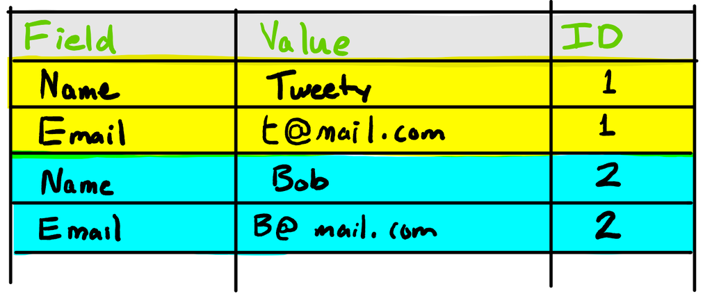

### dplyr: Wide Format

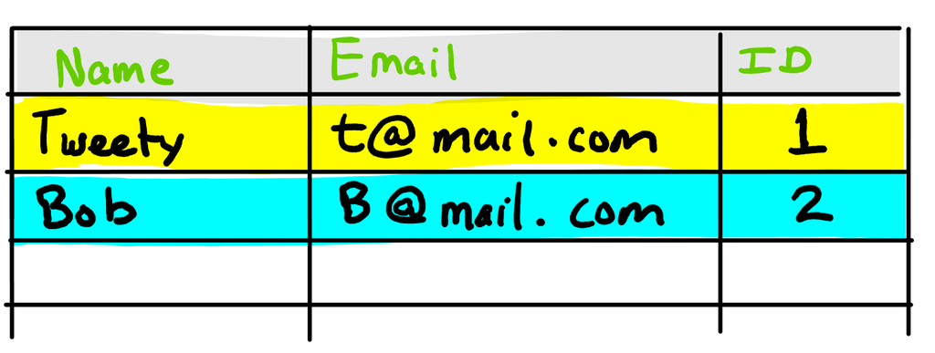

### Relational Databases

- Relationships are important
- Individual pieces of data are not duplicated (normalized)

### Example Duplication

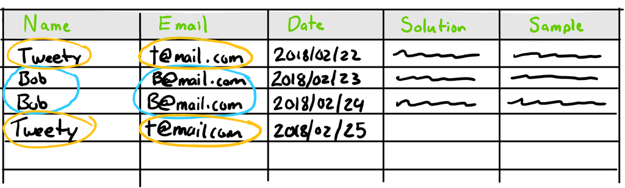

### Example Database Structure

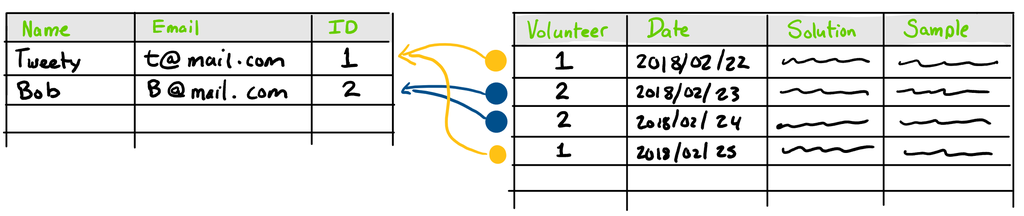

- Data is split into two sets:
  - Volunteer
  - Sample

### A mildly Complicated Relational example

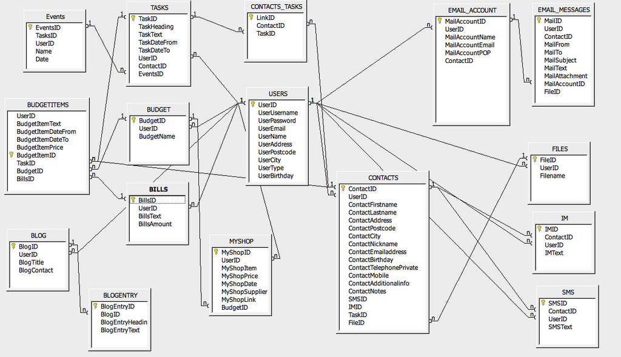

http://prp.wikidot.com/

### Joining Data

There are 6 types of joins that dplyr can use. We will talk about 3:

- Inner Join
- Left Join
- Right Join

### Joining Data

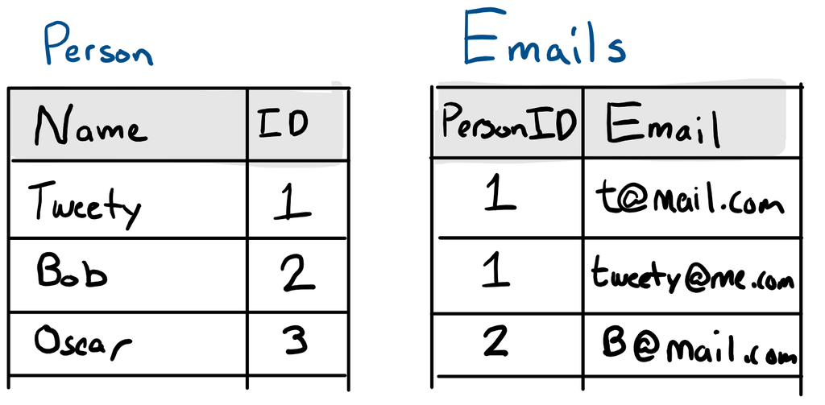

### Inner Join

These records have a match:

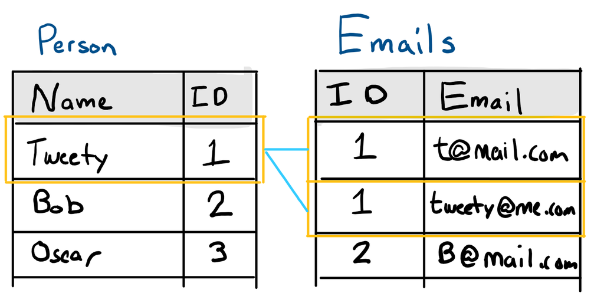

### Inner Join

So do these:

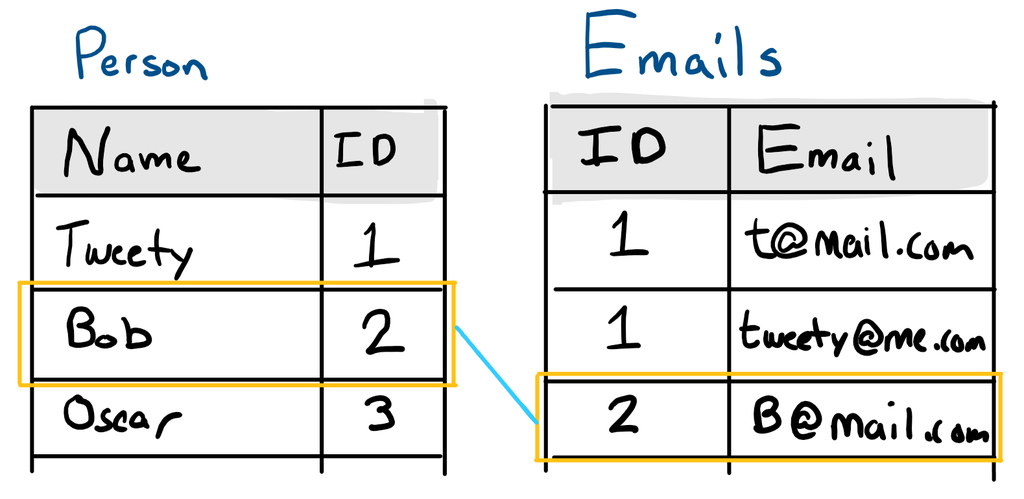

### Inner Join

But the third person does not

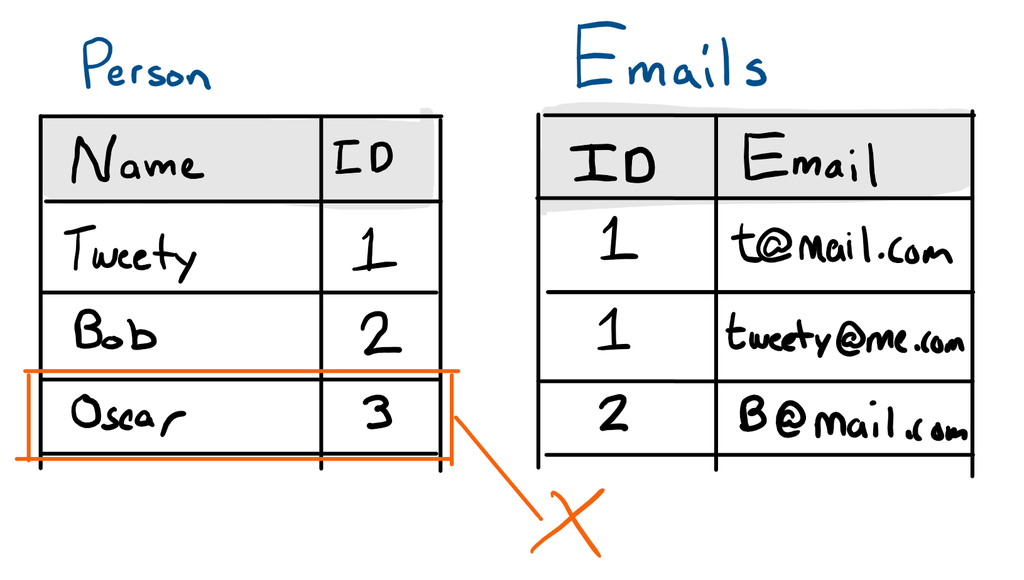

### Inner Join Results

The first person record has two emails. So how does the database resolve this situation?

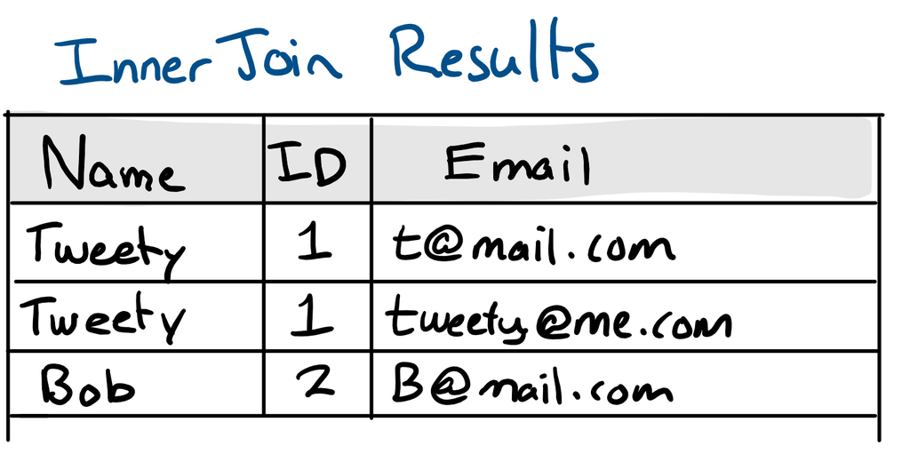

### Inner Join example

Let's find a player that was on the hall of fame ballot more than once and query for the amount of games they played in 1922 and 1923

```r
HallOfFame = tbl(db_connection, "HallOfFame")
```

```r
HallOfFame %>%
  inner_join(Batting, by="playerID", suffix=c(".hf", ".ba")) %>%
  filter(playerID=="adamssp01" & yearID.ba %in% c(1922, 1923)) %>%
  select(playerID, yearID.hf, G, yearID.ba)
```

```
# Source:   lazy query [?? x 4]
# Database: sqlite 3.22.0 [/tmp/RtmpNzBmhK/lahman.sqlite]
  playerID  yearID.hf     G yearID.ba
  <chr>         <int> <int>     <int>
1 adamssp01      1958    11      1922
2 adamssp01      1958    95      1923
3 adamssp01      1960    11      1922
4 adamssp01      1960    95      1923
```

### Left / Right Joins

The other type of joins I'll cover today are:

- Left Joins
- Right Joins

### Left Join

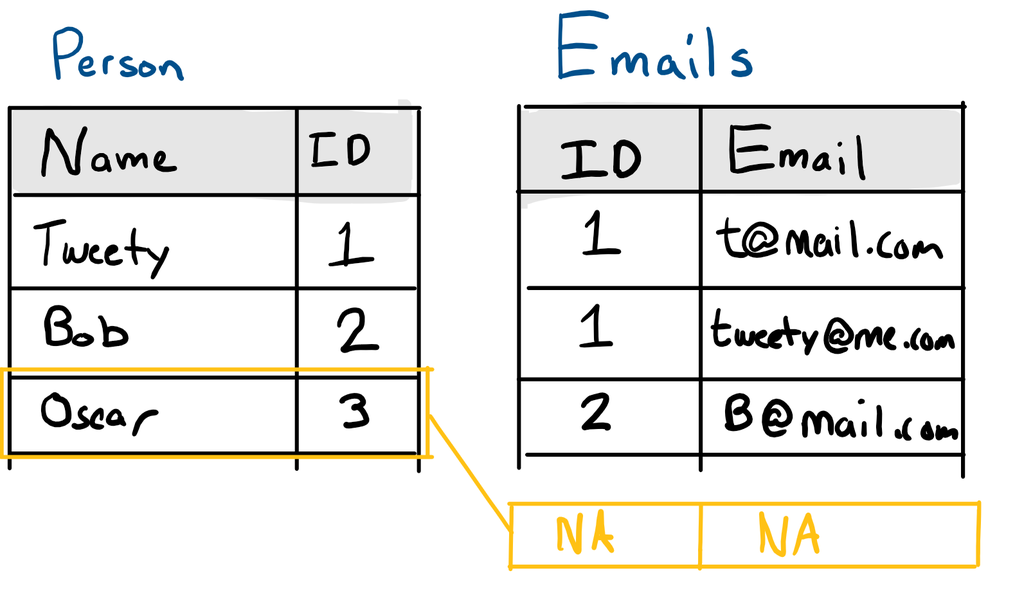

### Left Join Data Example

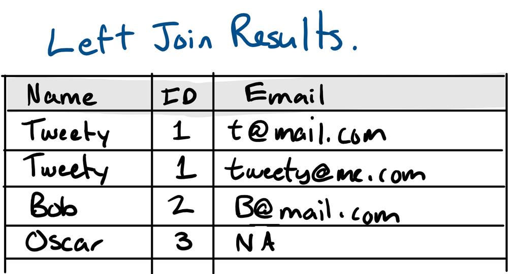

### Left Join Example

How many hits did Peter Rose have in regular and post season games per year.

```r
BattingPost = tbl(db_connection, "BattingPost")
```

```r
# use left join
Batting %>%
  left_join(BattingPost, by=c("yearID", "playerID"), suffix=c(".regular", ".postseason")) %>%
  filter(playerID=="rosepe01") %>%
  group_by(yearID) %>%
  summarise(
    playerID=playerID,
    regularH=H.regular,
    yearID=yearID,
    postH=sum(H.postseason, na.rm=TRUE)
  ) %>%
  select(playerID, yearID, regularH, postH)
```

### Left Join Example Output

```
# Source:   lazy query [?? x 4]
# Database: sqlite 3.22.0 [/tmp/RtmpNzBmhK/lahman.sqlite]
   playerID yearID regularH postH
   <chr>     <int>    <int> <int>
 1 rosepe01   1963      170    NA
 2 rosepe01   1964      139    NA
 3 rosepe01   1965      209    NA
 4 rosepe01   1966      205    NA
 5 rosepe01   1967      176    NA
 6 rosepe01   1968      210    NA
 7 rosepe01   1969      218    NA
 8 rosepe01   1970      205     8
 9 rosepe01   1971      192    NA
10 rosepe01   1972      198    15
# ... with more rows
```